# bmwAnalysis

## Analysis of BMW Global Sales

In this project, we use a dataset from [Kaggle](https://www.kaggle.com/datasets/payaldhokane/bmw-global-sales-and-market-data), which gives us information on

- sales volume
- vehicle models
- segments
- engine types
- pricing
- marketing spend
- dealership presence
- fuel prices
- and macro-economic indicators such as GDP growth and interest rates.

Note: This is a training dataset and does not correspond to the actual figures.

## Importing Required Libraries

```python
import numpy as np
import pandas as pd
import matplotlib.pyplot as plt
import seaborn as sns
import math

from sklearn.model_selection import train_test_split
from sklearn.preprocessing import OneHotEncoder
from sklearn.compose import ColumnTransformer
from sklearn.pipeline import Pipeline
from sklearn.linear_model import LinearRegression
from sklearn.metrics import r2_score,mean_squared_error, mean_absolute_error


sns.set_theme(style="whitegrid")
plt.rcParams['figure.figsize'] = (10,6)
sns.set_palette("muted")
```

## Basic Information about the Dataset

```python
df = pd.read_csv('bmw_global_sales_dataset.csv')
df.head()
```

|  | year | month | country | model | segment | engine_type | price_usd | marketing_spend_usd | dealership_count | fuel_price_usd | gdp_growth_percent | interest_rate_percent | competition_index | units_sold |
| --- | --- | --- | --- | --- | --- | --- | --- | --- | --- | --- | --- | --- | --- | --- |
| 0 | 2021 | 1 | Australia | X1 | SUV | Petrol | 82234 | 315372 | 96 | 0.97 | 6.29 | 1.2 | 8 | 324 |
| 1 | 2018 | 8 | Australia | i4 | Sedan | Electric | 82291 | 447798 | 234 | 0.97 | 6.29 | 1.2 | 7 | 556 |
| 2 | 2022 | 12 | USA | 5 Series | Electric | Hybrid | 40594 | 259755 | 25 | 0.97 | 6.29 | 1.2 | 7 | 152 |
| 3 | 2019 | 11 | Australia | i7 | SUV | Electric | 42371 | 323541 | 319 | 0.97 | 6.29 | 1.2 | 5 | 730 |
| 4 | 2021 | 12 | Brazil | X5 | SUV | Diesel | 82315 | 482015 | 367 | 0.97 | 6.29 | 1.2 | 2 | 1156 |

```python
df.info()
```

```
<class 'pandas.core.frame.DataFrame'>
RangeIndex: 1000 entries, 0 to 999
Data columns (total 14 columns):
 #   Column                 Non-Null Count  Dtype
---  ------                 --------------  -----
 0   year                   1000 non-null   int64
 1   month                  1000 non-null   int64
 2   country                1000 non-null   object
 3   model                  1000 non-null   object
 4   segment                1000 non-null   object
 5   engine_type            1000 non-null   object
 6   price_usd              1000 non-null   int64
 7   marketing_spend_usd    1000 non-null   int64
 8   dealership_count       1000 non-null   int64
 9   fuel_price_usd         1000 non-null   float64
 10  gdp_growth_percent     1000 non-null   float64
 11  interest_rate_percent  1000 non-null   float64
 12  competition_index      1000 non-null   int64
 13  units_sold             1000 non-null   int64
dtypes: float64(3), int64(7), object(4)
memory usage: 109.5+ KB
```

```python
df.describe()
```

|  | year | month | price_usd | marketing_spend_usd | dealership_count | fuel_price_usd | gdp_growth_percent | interest_rate_percent | competition_index | units_sold |
| --- | --- | --- | --- | --- | --- | --- | --- | --- | --- | --- |
| count | 1000.000000 | 1000.000000 | 1000.000000 | 1000.000000 | 1000.000000 | 1.000000e+03 | 1.000000e+03 | 1.000000e+03 | 1000.000000 | 1000.000000 |
| mean | 2019.448000 | 6.487000 | 76535.747000 | 279492.230000 | 200.230000 | 9.700000e-01 | 6.290000e+00 | 1.200000e+00 | 5.572000 | 633.192000 |
| std | 2.912005 | 3.510863 | 25360.933749 | 127010.559722 | 113.096127 | 1.977186e-14 | 3.199042e-14 | 2.265988e-14 | 2.944059 | 263.346628 |
| min | 2015.000000 | 1.000000 | 35060.000000 | 50363.000000 | 10.000000 | 9.700000e-01 | 6.290000e+00 | 1.200000e+00 | 1.000000 | 15.000000 |
| 25% | 2017.000000 | 3.000000 | 54578.750000 | 173552.250000 | 101.750000 | 9.700000e-01 | 6.290000e+00 | 1.200000e+00 | 3.000000 | 432.750000 |
| 50% | 2019.000000 | 7.000000 | 75726.000000 | 278733.500000 | 197.000000 | 9.700000e-01 | 6.290000e+00 | 1.200000e+00 | 6.000000 | 630.000000 |
| 75% | 2022.000000 | 10.000000 | 98730.250000 | 390110.000000 | 297.000000 | 9.700000e-01 | 6.290000e+00 | 1.200000e+00 | 8.000000 | 842.500000 |
| max | 2024.000000 | 12.000000 | 119817.000000 | 498927.000000 | 399.000000 | 9.700000e-01 | 6.290000e+00 | 1.200000e+00 | 10.000000 | 1242.000000 |

## EDA (Exploratory Data Analysis)

From the analysis performed, we have gained the following insights:

1. The mean prices of Electric, SUV and Sedans are almost equal, with similar sales in all 3.
2. The mean price of Petrol cars are higher than Electric, Hybrid and Diesel, all 3 of which have almost similar distributions.
3. The X3, 3 Series and the i4 are the top 3 selling models
4. Top 5 after marketing revenue makers are:
   1. X3 Electric
   2. X5 Electric
   3. 3 Series Petrol
   4. i4 Hybrid
   5. i4 Petrol
5. Least 5 after marketing revenue markers are:
   1. iX Electric
   2. iX Petrol
   3. X7 Petrol
   4. X7 Hybrid
   5. i7 Hybrid
6. Top 5 Countries by Revenue & Units Sold
   1. China (~6.072B)
   2. UK (~5.488B)
   3. France (~5.029B)
   4. India (~4,972B)
   5. Brazil (~4.959B)
7. Units Sold by Year does not seem to follow a trend. We need more information to learn about the random dips and boosts in sales.
8. We have observed a positive linear relationship between Units Sold and Number of Dealerships
9. Highest Average Sale is around the end of the year (Nov, Dec) which makes sense as it is around the vacation as well as bonus time.

```python
# Total Cars from each segment
df['segment'].value_counts()
```

```
segment
Electric    341
SUV         331
Sedan       328
Name: count, dtype: int64
```

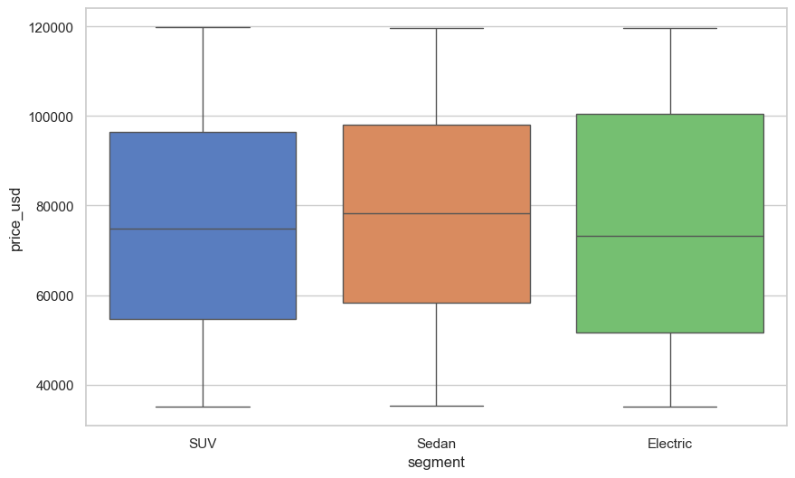

```
Mean Prices are:
segment
Electric    76022.278592
SUV         75351.700906
Sedan       78264.442073
Name: price_usd, dtype: float64
```

```python
# Plot between Price and Segment

sns.boxplot(x='segment',y='price_usd',data = df,hue = 'segment',)
plt.show()

mean_prices = df.groupby('segment')['price_usd'].mean()
print(f"Mean Prices are: \n{mean_prices}")
```

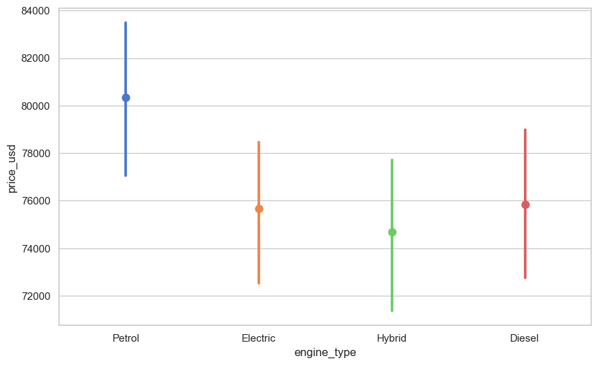

```
Mean Prices based on Engine Type:
engine_type
Diesel      75835.772908
Electric    75667.635338
Hybrid      74673.686508
Petrol      80327.307359
Name: price_usd, dtype: float64
```

```python
# Plot between Engine Type and Price

sns.pointplot(data = df, x='engine_type', y= 'price_usd', hue = 'engine_type')
plt.show()

mean_price_ET = df.groupby('engine_type')['price_usd'].mean()
print(f"Mean Prices based on Engine Type:\n{mean_price_ET}")
```

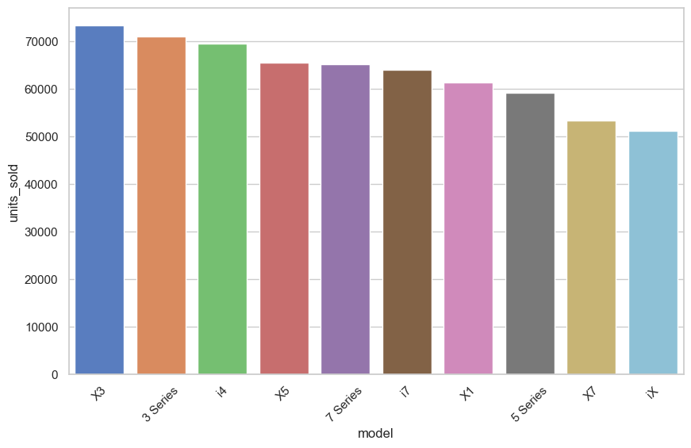

|  | model | units_sold |
| --- | --- | --- |
| 4 | X3 | 73358 |
| 0 | 3 Series | 70886 |
| 7 | i4 | 69528 |
| 5 | X5 | 65505 |
| 2 | 7 Series | 65071 |

```python
# Sales by Model
model_sales = df.groupby('model')['units_sold'].sum().reset_index().sort_values(by = 'units_sold',ascending=False)

sns.barplot(data = model_sales, x= 'model',y='units_sold', hue = 'model')
plt.xticks(rotation = 45)
plt.show()

model_sales.head()
```

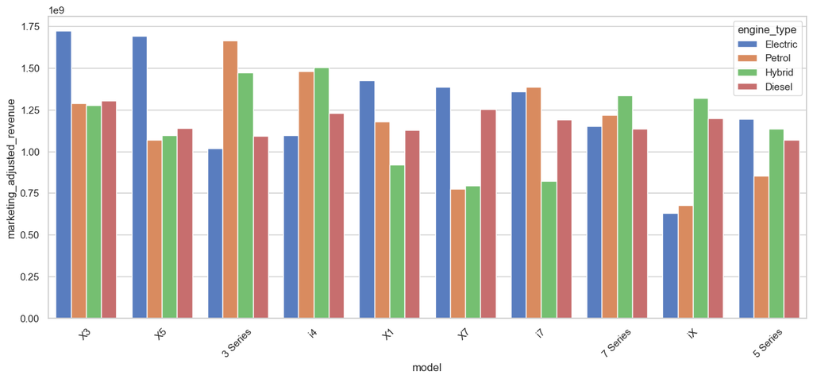

```
Top 5 Profitable Cars:
```

|  | model | engine_type | marketing_spend_usd | revenue | marketing_adjusted_revenue |
| --- | --- | --- | --- | --- | --- |
| 17 | X3 | Electric | 10279398 | 1734864617 | 1724585219 |
| 21 | X5 | Electric | 10455463 | 1703146426 | 1692690963 |
| 3 | 3 Series | Petrol | 10633786 | 1674089530 | 1663455744 |
| 30 | i4 | Hybrid | 9484093 | 1513094487 | 1503610394 |
| 31 | i4 | Petrol | 8376949 | 1489779099 | 1481402150 |

```
Least Profitable Cars:
```

|  | model | engine_type | marketing_spend_usd | revenue | marketing_adjusted_revenue |
| --- | --- | --- | --- | --- | --- |
| 34 | i7 | Hybrid | 4189124 | 824754549 | 820565425 |
| 26 | X7 | Hybrid | 6150842 | 799311098 | 793160256 |
| 27 | X7 | Petrol | 4184351 | 780137918 | 775953567 |
| 39 | iX | Petrol | 3361467 | 681169186 | 677807719 |
| 37 | iX | Electric | 3628400 | 633557732 | 629929332 |

```python
# Creating a column 'revenue' and grouping to find out which model,fuel type combination made the most after marketing revenue
df['revenue'] = df['price_usd']*df['units_sold']

grouped = (
    df.groupby(['model', 'engine_type'])
      .agg({
          'marketing_spend_usd': 'sum',
          'revenue': 'sum'

      })
      .reset_index()
)

grouped['marketing_adjusted_revenue']=grouped['revenue']-grouped['marketing_spend_usd']
grouped = grouped.sort_values(by='marketing_adjusted_revenue', ascending=False)

plt.figure(figsize=(15,6))
sns.barplot(data=grouped,x='model',y='marketing_adjusted_revenue',hue='engine_type')
plt.xticks(rotation = 45)
plt.show()

print("Top 5 Profitable Cars: ")
display(grouped.head())

print("Least Profitable Cars: ")
display(grouped.tail())
```

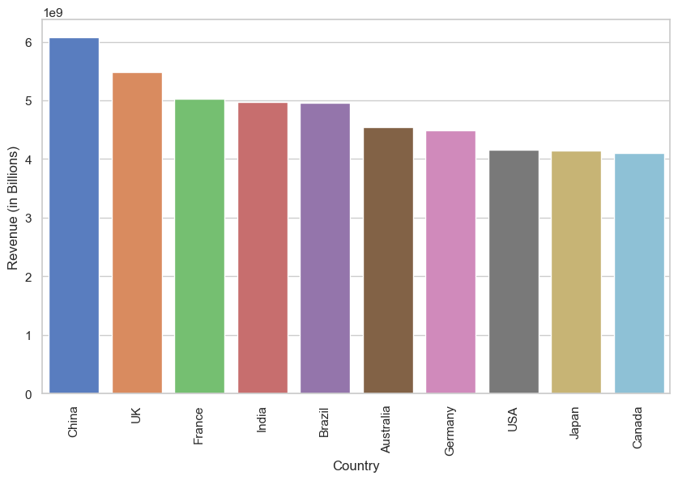

|  | country | revenue |
| --- | --- | --- |
| 0 | China | 6072297993 |
| 1 | UK | 5487964042 |
| 2 | France | 5029553241 |
| 3 | India | 4972431297 |
| 4 | Brazil | 4959349000 |
| 5 | Australia | 4549509804 |
| 6 | Germany | 4493222982 |
| 7 | USA | 4160873752 |
| 8 | Japan | 4143581597 |
| 9 | Canada | 4100380992 |

```python
# Revenue based on Country

df['revenue'] = df['price_usd']*df['units_sold']

country_revenue = df.groupby('country')['revenue'].sum().sort_values(ascending=False).reset_index()


plt.figure(figsize=(10,6))
sns.barplot(data = country_revenue, x='country',y='revenue',hue='country')
plt.xticks(rotation = 90)
plt.xlabel('Country')
plt.ylabel('Revenue (in Billions)')
plt.show()

display(country_revenue)
```

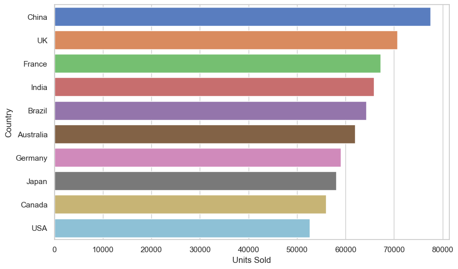

|  | country | units_sold |
| --- | --- | --- |
| 0 | China | 77488 |
| 1 | UK | 70639 |
| 2 | France | 67173 |
| 3 | India | 65898 |
| 4 | Brazil | 64331 |
| 5 | Australia | 61987 |
| 6 | Germany | 59006 |
| 7 | Japan | 58076 |
| 8 | Canada | 55947 |
| 9 | USA | 52647 |

```python
# Sales based on Country

country_units_sold = df.groupby('country')['units_sold'].sum().sort_values(ascending=False).reset_index()

plt.figure(figsize=(10,6))
sns.barplot(data = country_units_sold,y='country',x='units_sold',hue='country')
plt.xlabel('Units Sold')
plt.ylabel('Country')
plt.show()

display(country_units_sold)
```

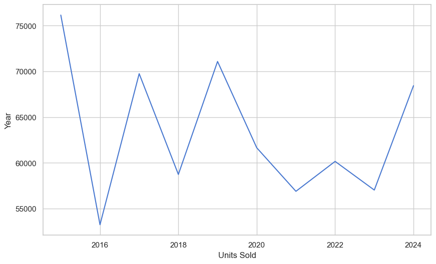

|  | year | units_sold |
| --- | --- | --- |
| 0 | 2015 | 76157 |
| 1 | 2019 | 71089 |
| 2 | 2017 | 69755 |
| 3 | 2024 | 68440 |
| 4 | 2020 | 61657 |
| 5 | 2022 | 60168 |
| 6 | 2018 | 58742 |
| 7 | 2023 | 57036 |
| 8 | 2021 | 56899 |
| 9 | 2016 | 53249 |

```python
# Sales by Year

sales_by_year = df.groupby('year')['units_sold'].sum().sort_values(ascending=False).reset_index()

sns.lineplot(data=sales_by_year,x='year',y='units_sold')
plt.xlabel('Units Sold')
plt.ylabel('Year')
plt.show()

display(sales_by_year)
```

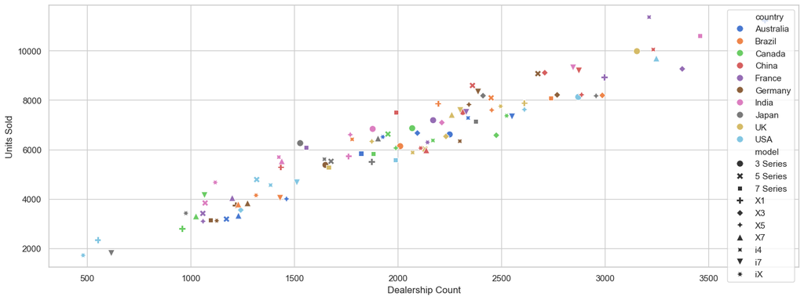

```python
# Units Sold and Dealership count by Country and Model

sales_dealership = df.groupby(['model','country']).agg({
    'units_sold' : 'sum',
    'dealership_count' : 'sum'
}).reset_index()

plt.figure(figsize=(17,6))
sns.scatterplot(data=sales_dealership,x='dealership_count',y='units_sold',hue='country',style='model',s=70)
plt.xlabel('Dealership Count')
plt.ylabel('Units Sold')
plt.legend()
plt.show()
```

We can see a positive linear relationship between Dealership Count and Units Sold

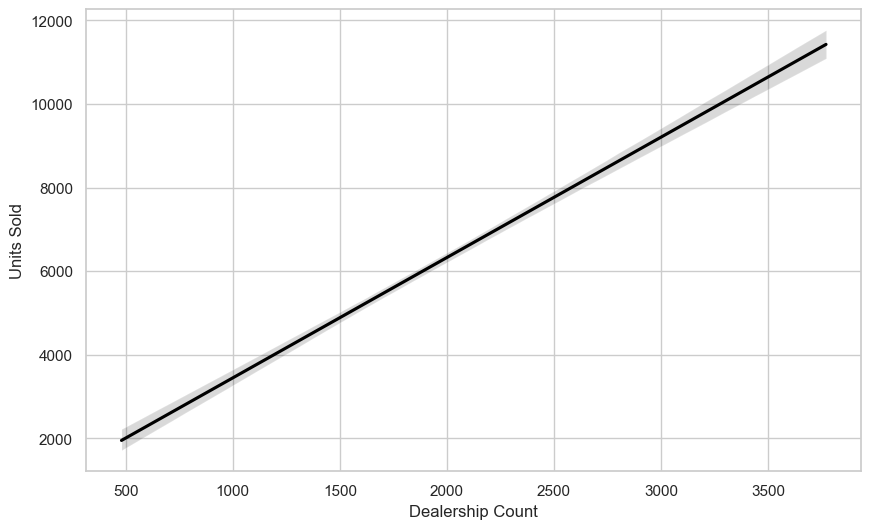

```python
sns.regplot(data=sales_dealership,x='dealership_count',y='units_sold',color = 'black',scatter=False)
plt.xlabel('Dealership Count')
plt.ylabel('Units Sold')
plt.show()
```

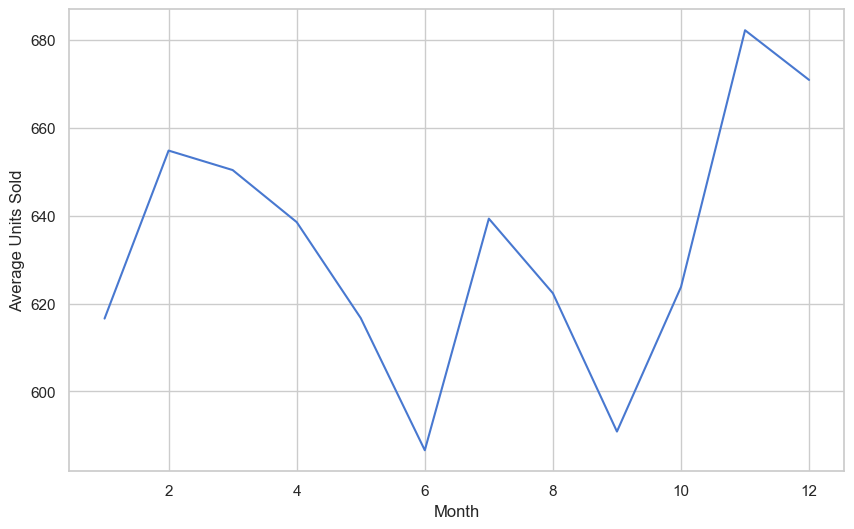

|  | month | units_sold |
| --- | --- | --- |
| 10 | 11 | 682.178571 |
| 11 | 12 | 670.875000 |
| 1 | 2 | 654.800000 |
| 2 | 3 | 650.367089 |
| 6 | 7 | 639.313253 |
| 3 | 4 | 638.521127 |
| 9 | 10 | 623.765432 |
| 7 | 8 | 622.337209 |
| 4 | 5 | 616.682927 |
| 0 | 1 | 616.573034 |
| 8 | 9 | 590.865854 |
| 5 | 6 | 586.612500 |

```python
# Units Sold based on Month of Year

month_sales = df.groupby('month')['units_sold'].mean().reset_index().sort_values(by='units_sold',ascending=False)

sns.lineplot(data=month_sales,x='month',y='units_sold')
plt.ylabel('Average Units Sold')
plt.xlabel('Month')
plt.show()

display(month_sales)
```

## Training Model

R2 > 0.7 => Strong model

```python
# Define X and y
X = df[['price_usd', 'marketing_spend_usd', 'dealership_count',
        'competition_index', 'segment', 'engine_type', 'country']]

y = df['units_sold']

# Encode BEFORE splitting
X_encoded = pd.get_dummies(X, drop_first=True)

# Split
X_train, X_test, y_train, y_test = train_test_split(
    X_encoded, y, test_size=0.2, random_state=42
)

# Train
lm = LinearRegression()
lm.fit(X_train, y_train)

# Predict on TEST only
y_pred = lm.predict(X_test)

# Evaluate
print("R²:", r2_score(y_test, y_pred))
print("MAE:", mean_absolute_error(y_test, y_pred))
print("MSE:", mean_squared_error(y_test, y_pred))
print("RMSE:", np.sqrt(mean_squared_error(y_test, y_pred)))
```

```
R²: 0.763333990789347
MAE: 108.50769770839354
MSE: 16177.38455570668
RMSE: 127.1903477301115
```

```python
coef_df = pd.DataFrame({
    'Feature': X_train.columns,
    'Coefficient': lm.coef_
}).sort_values('Coefficient', ascending=False)

print(coef_df)
```

[output not shown]

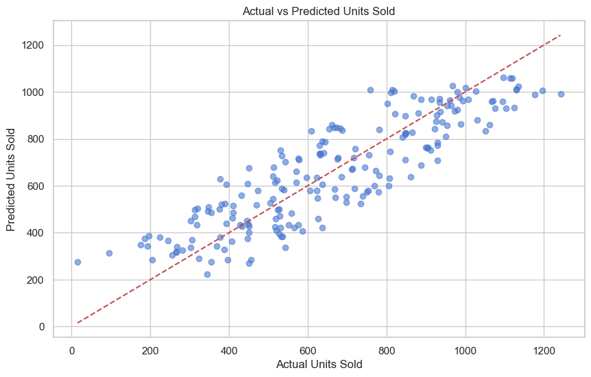

```python
plt.scatter(y_test, y_pred, alpha=0.6)
plt.plot([y_test.min(), y_test.max()], [y_test.min(), y_test.max()], 'r--')  # perfect prediction line
plt.xlabel("Actual Units Sold")
plt.ylabel("Predicted Units Sold")
plt.title("Actual vs Predicted Units Sold")
plt.show()
```